# AnalyseGEM

edmar.teixeira@me.com

Sunday, December 07, 2014

# Background

## Aim

Quantify **uncertanty** (sensitivity of model to?) coming from the choice of (possible?) **sowing dates and maize hybrids** in regional simulations

## Method

> Use APSIM 7.4

> Run at 5 different sowng dates (1-Sep, 1-Oct, 1-Nov, 1-Dec, 1-Jan)

# Data Manipulation

## Retrieve data and check

> Subset to keep only maize (exclude winter forage wheat) and order factors

## Graph some results

> Total silage biomass by sowing date (kg/ha)

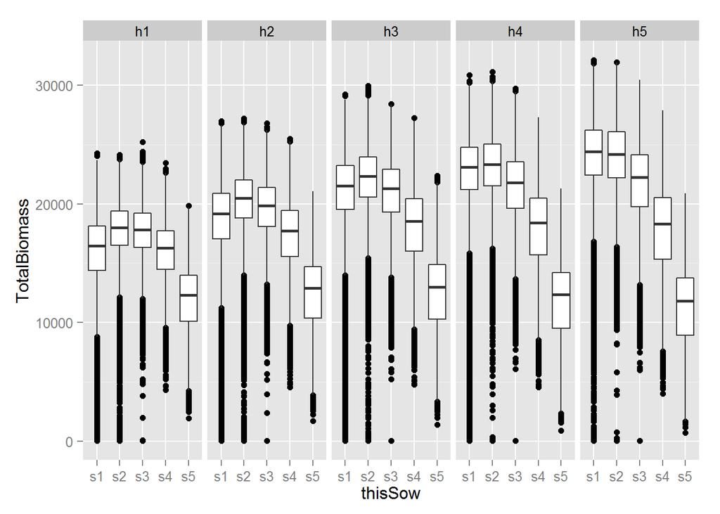

```r
# Pooled response to sow date
ggplot(workDF, aes(x= thisSow , y=TotalBiomass)) +  geom_boxplot() +
facet_grid( .~ thisHyb)
```

> Total silage biomass by hybrid type (kg/ha)

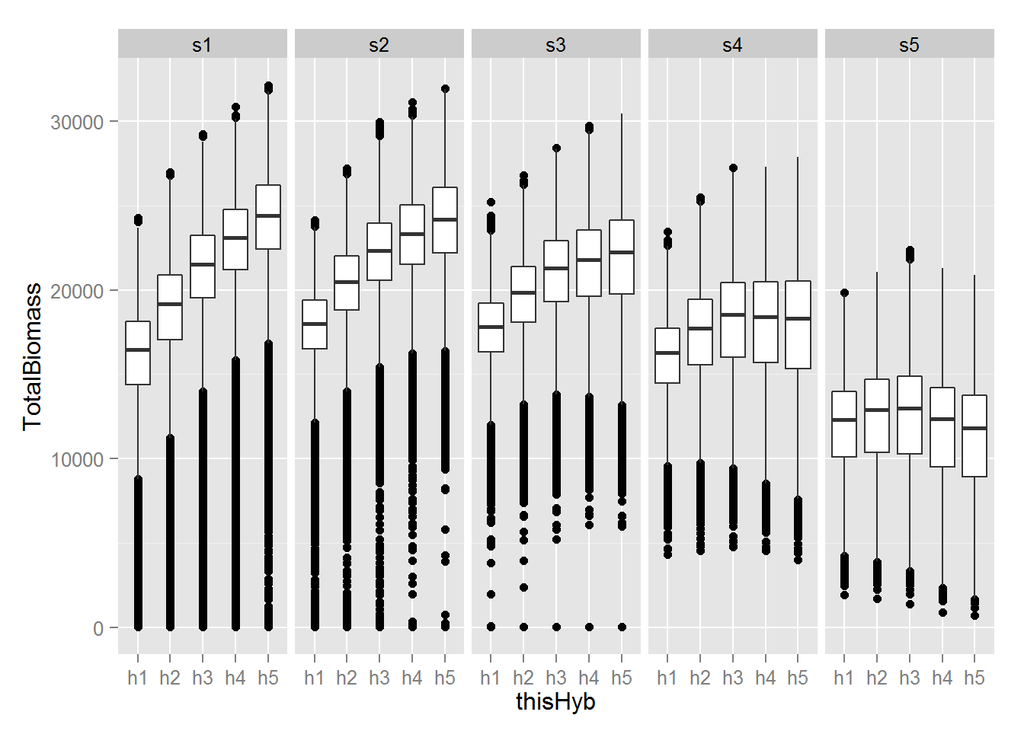

```r
# Pooled response to Hybrid (Bio)
ggplot(workDF, aes(x= thisHyb , y=TotalBiomass)) +  geom_boxplot() +
facet_grid( .~ thisSow)
```

> Total **grain yield** by hybrid type (kg/ha)

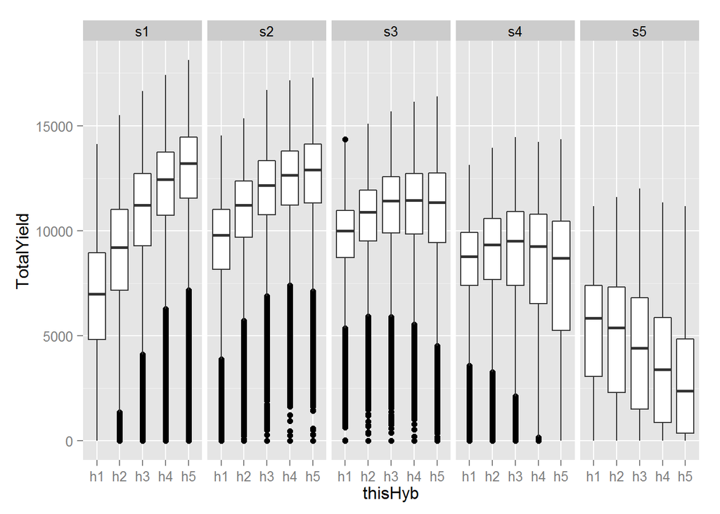

```r
# Pooled response to Hybrid (Bio)
ggplot(workDF, aes(x= thisHyb , y=TotalYield)) +  geom_boxplot() +
facet_grid( .~ thisSow)
```

> Harvest index by hybrid type

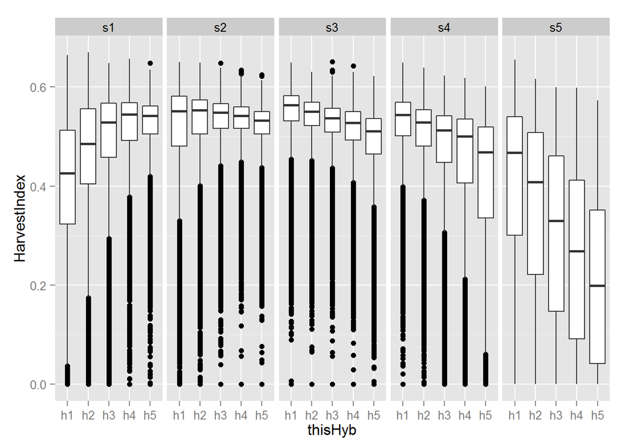

```r
# Pooled response to Hybrid (HI)
ggplot(workDF, aes(x= thisHyb , y=HarvestIndex)) +  geom_boxplot() +
facet_grid( .~ thisSow)
```

# Analysis

## Calculate variability

> Just to have an initial idea of variability

> Considers variation among YEARS and PIXELS together

> Pooled among hybrids and sowing dates

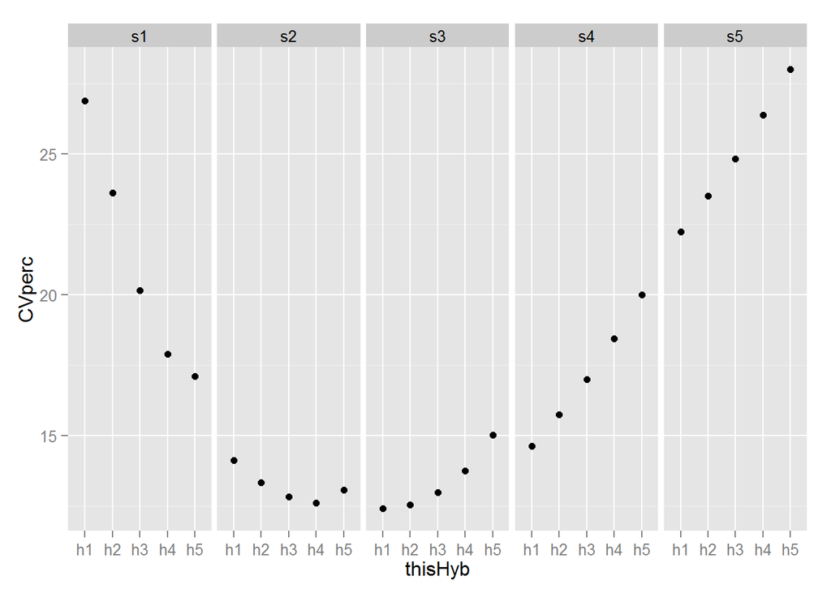

```r
# polled CV across hybrids and sowing dates
cvTable = workDF %>%
  group_by(thisSow, thisHyb) %>%
  summarise(CVperc = sd(TotalBiomass, na.rm = TRUE)/mean(TotalBiomass, na.rm = TRUE)*100)

ggplot(cvTable, aes(x= thisHyb , y=CVperc)) +  geom_point() +
facet_grid( .~ thisSow)
```

## Values pooled (median, mean, stdev) across **years**

> Statistics of n years per pixel/scenario of hybrid and sow date combination

> Also creates a ID for each pixel-h-s combination (FIXME: maybe redundant now)

```r
# Create a median and stdev for each pixel-h-s, polled across YEARS (i.e. year is not included in grouping)

workDF_med = workDF %>%
  group_by(row,col,thisHyb,thisSow) %>%
  summarise( thisLat = mean(thisLat, na.rm = TRUE),
             thisLong = mean(thisLong, na.rm = TRUE),
             Bio_mean = mean(TotalBiomass, na.rm = TRUE),
             Bio_med = median(TotalBiomass, na.rm = TRUE),
             Bio_sdv = sd(TotalBiomass, na.rm = TRUE),
             Bio_cv = (Bio_sdv/Bio_mean)*100,
             Y_mean = mean(TotalYield, na.rm = TRUE),
             Y_med = median(TotalYield, na.rm = TRUE),
             Y_sdv = sd(TotalYield, na.rm = TRUE),
             Y_cv = (Y_sdv/Y_mean)*100,
             HI_med = median(HarvestIndex, na.rm = TRUE)) %>%
  # Unique ID for the pixel in a hxs scenario (FIXME: maybe redundant now)
  mutate(pixel_scenID=paste0(row,"_",col,"_",thisHyb,"_",thisSow),
         pixel_ID=paste0(row,"_",col))

# make hybrid and sow date as numbers (for using in raster later) - FIXME: do this prettier later
workDF_med$thisSow_n[workDF_med$thisSow == "s1"] <- 1
workDF_med$thisSow_n[workDF_med$thisSow == "s2"] <- 2
workDF_med$thisSow_n[workDF_med$thisSow == "s3"] <- 3
workDF_med$thisSow_n[workDF_med$thisSow == "s4"] <- 4
workDF_med$thisSow_n[workDF_med$thisSow == "s5"] <- 5

workDF_med$thisHyb_n[workDF_med$thisHyb == "h1"] <- 1
workDF_med$thisHyb_n[workDF_med$thisHyb == "h2"] <- 2
workDF_med$thisHyb_n[workDF_med$thisHyb == "h3"] <- 3
workDF_med$thisHyb_n[workDF_med$thisHyb == "h4"] <- 4
workDF_med$thisHyb_n[workDF_med$thisHyb == "h5"] <- 5

head(workDF_med)
```

```
## Source: local data frame [6 x 19]
## Groups: row, col, thisHyb
##
##   row col thisHyb thisSow thisLat thisLong Bio_mean  Bio_med   Bio_sdv
## 1   6 132      h1      s1 -34.625  172.975 16734.28 16662.14  783.1115
## 2   6 132      h1      s2 -34.625  172.975 17045.89 17048.38 1041.5299
## 3   6 132      h1      s3 -34.625  172.975 16139.87 16328.43 1059.5998
## 4   6 132      h1      s4 -34.625  172.975 14875.02 14780.23 1140.5605
## 5   6 132      h1      s5 -34.625  172.975 12494.61 12681.45  896.6704
## 6   6 132      h2      s1 -34.625  172.975 18991.37 18921.95 1031.3620
## Variables not shown: Bio_cv (dbl), Y_mean (dbl), Y_med (dbl), Y_sdv (dbl),
##   Y_cv (dbl), HI_med (dbl), pixel_scenID (chr), pixel_ID (chr), thisSow_n
##   (dbl), thisHyb_n (dbl)
```

## Find hybrid x sow date with **highest yield** in each pixel

> This is to check the data “sensibility”

> FIXME: Check this dplyr script and logic as it seems that almost **NO variation** is coming from this

> Most productive sowing dates are **S1 (Sept) and S2 (Oct)**

```
## Source: local data frame [6 x 19]
## Groups: row, col
##
##   row col thisHyb thisSow thisLat thisLong Bio_mean  Bio_med  Bio_sdv
## 1   6 132      h5      s1 -34.625  172.975 23300.65 23221.44 1176.951
## 2   7 133      h5      s1 -34.675  173.025 23147.82 23259.51 1161.541
## 3   8 133      h5      s1 -34.725  173.025 23059.12 22883.02 1188.485
## 4  10 135      h5      s1 -34.825  173.125 21733.47 21663.88 1256.973
## 5  11 139      h5      s1 -34.875  173.325 24218.78 24215.18 1087.084
## 6  12 136      h5      s1 -34.925  173.175 22285.92 22130.94 1170.183
## Variables not shown: Bio_cv (dbl), Y_mean (dbl), Y_med (dbl), Y_sdv (dbl),
##   Y_cv (dbl), HI_med (dbl), pixel_scenID (chr), pixel_ID (chr), thisSow_n
##   (dbl), thisHyb_n (dbl)
```

```
## [1] 2766
```

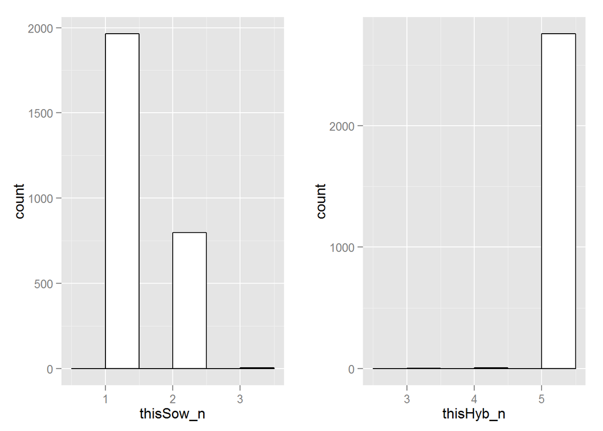

## Find highest **grain yield** per pixel

> Allmost same results for grain

```
## Source: local data frame [25 x 19]
## Groups: row, col
##
##    row col thisHyb thisSow thisLat thisLong Bio_mean  Bio_med  Bio_sdv
## 1    6 132      h5      s1 -34.625  172.975 23300.65 23221.44 1176.951
## 2    7 133      h5      s1 -34.675  173.025 23147.82 23259.51 1161.541
## 3    8 133      h5      s2 -34.725  173.025 22137.04 22190.18 1155.506
## 4   10 135      h5      s2 -34.825  173.125 20851.21 20938.03 1089.962
## 5   11 139      h5      s1 -34.875  173.325 24218.78 24215.18 1087.084
## 6   12 136      h5      s2 -34.925  173.175 21465.17 21392.79 1139.295
## 7   13 140      h5      s1 -34.975  173.375 22206.51 22178.72 1154.764
## 8   14 137      h5      s1 -35.025  173.225 21849.15 21988.26 1162.813
## 9   14 138      h5      s1 -35.025  173.275 21499.16 21323.28 1207.366
## 10  14 141      h5      s1 -35.025  173.425 20972.40 20867.22 1274.605
## 11  14 147      h5      s1 -35.025  173.725 24323.29 24296.47 1442.683
```

[output cut: 17 more lines]

```
## [1] 2766
```

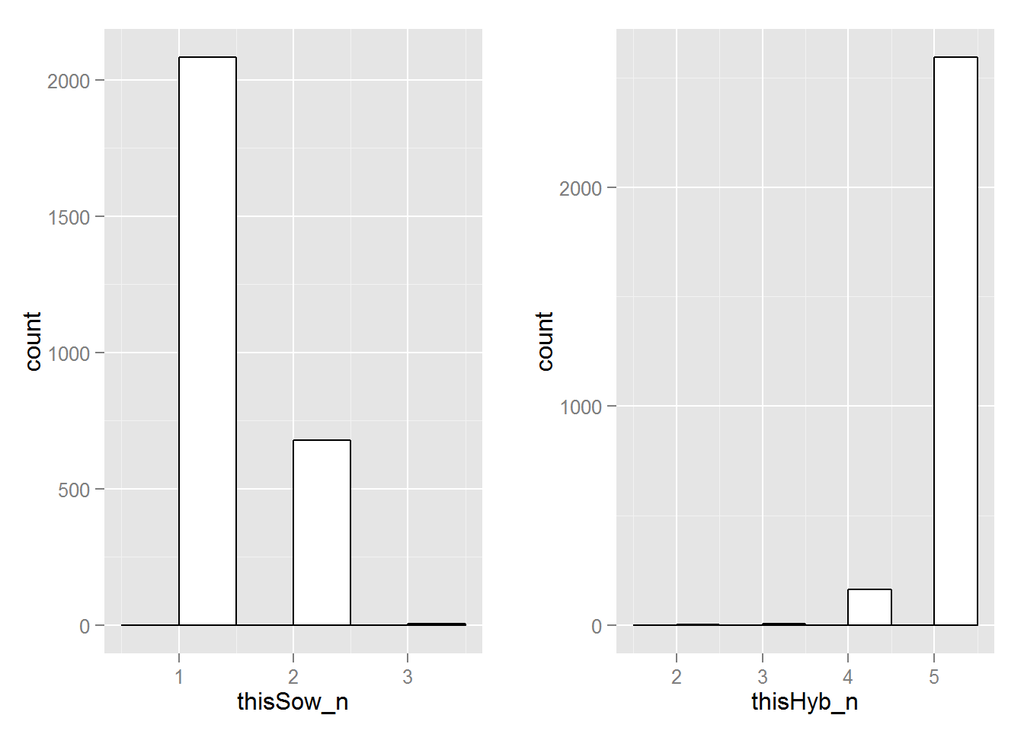

## Find hybrid x sow date with **lowest inter-annual variability** in each pixel

> A bit more spread of frequencies here

> In most pixels, sowing date 2 and 3 are less variable

> Longer hybrids (Hybrid 3,4 and 5) are less variable

```r
df_minSd <- workDF_med %>% group_by(row, col) %>%
#  filter(Bio_sdv == min(Bio_sdv))
 filter(Bio_cv == min(Bio_cv))

head(df_minSd)
```

```
## Source: local data frame [6 x 19]
## Groups: row, col
##
##   row col thisHyb thisSow thisLat thisLong Bio_mean  Bio_med   Bio_sdv
## 1   6 132      h1      s1 -34.625  172.975 16734.28 16662.14  783.1115
## 2   7 133      h5      s2 -34.675  173.025 22263.35 22438.48 1047.8436
## 3   8 133      h3      s1 -34.725  173.025 20880.98 20920.28 1058.2905
## 4  10 135      h5      s2 -34.825  173.125 20851.21 20938.03 1089.9623
## 5  11 139      h4      s1 -34.875  173.325 22874.64 22774.52  988.6627
## 6  12 136      h4      s1 -34.925  173.175 21285.74 21212.99 1020.2991
## Variables not shown: Bio_cv (dbl), Y_mean (dbl), Y_med (dbl), Y_sdv (dbl),
##   Y_cv (dbl), HI_med (dbl), pixel_scenID (chr), pixel_ID (chr), thisSow_n
##   (dbl), thisHyb_n (dbl)
```

```r
nrow(df_minSd)
```

```
## [1] 2766
```

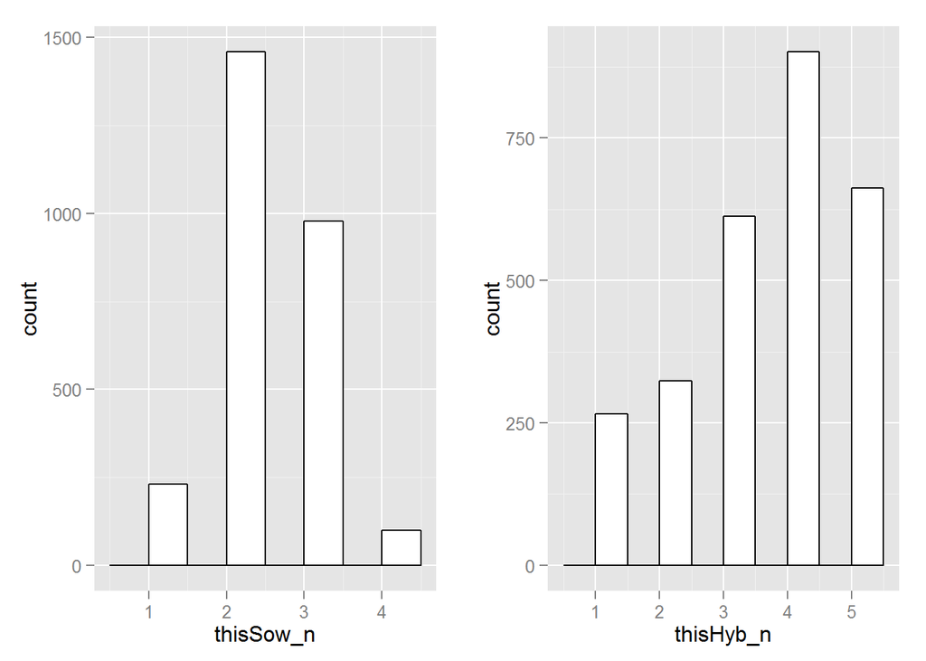

```r
#summary(df_minSd)

#summary(df_maxY)

#PLot histograms
hg1 = ggplot(df_minSd, aes(x=thisSow_n)) + geom_histogram(binwidth=.5, colour="black", fill="white")
hg2 =ggplot(df_minSd, aes(x=thisHyb_n)) + geom_histogram(binwidth=.5, colour="black", fill="white")


# Plot distributions of Si
require(gridExtra)
grid.arrange(hg1, hg2, ncol=2)
```

# How is total biomass and inter-annual variability related?

> In general **highest** yields have **lowest variability**

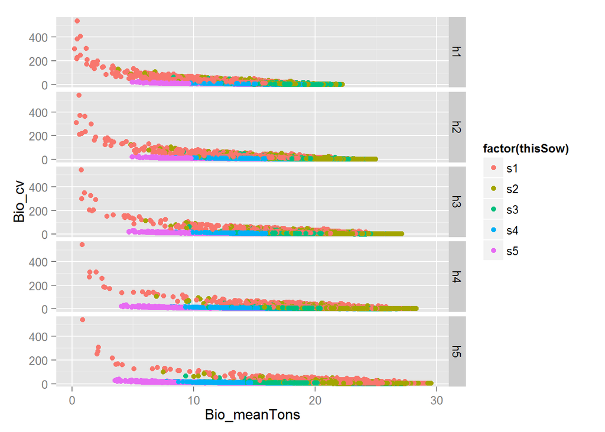

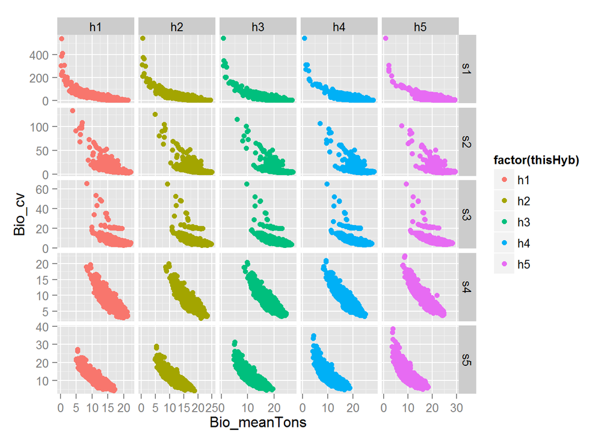

# Rasterise for mapping

> Checking data-frame

> Plot statistics for n Years

## Pixels with highest Total Silage Biomass

> Maps show stats and which hybrid and sowing date was selected in each pixel

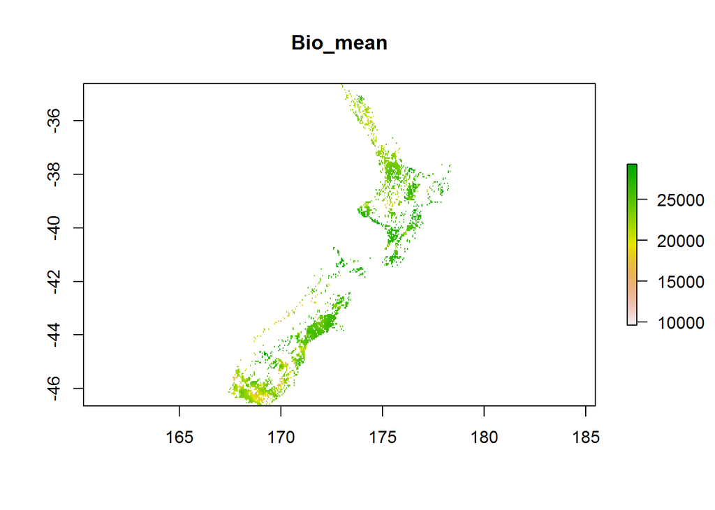

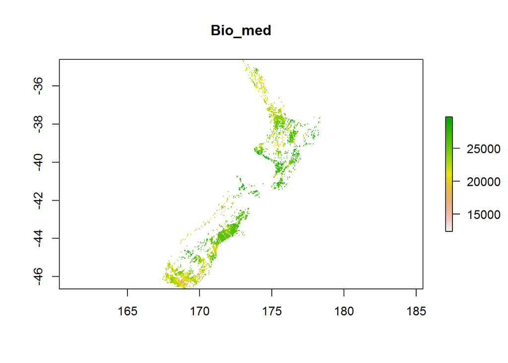

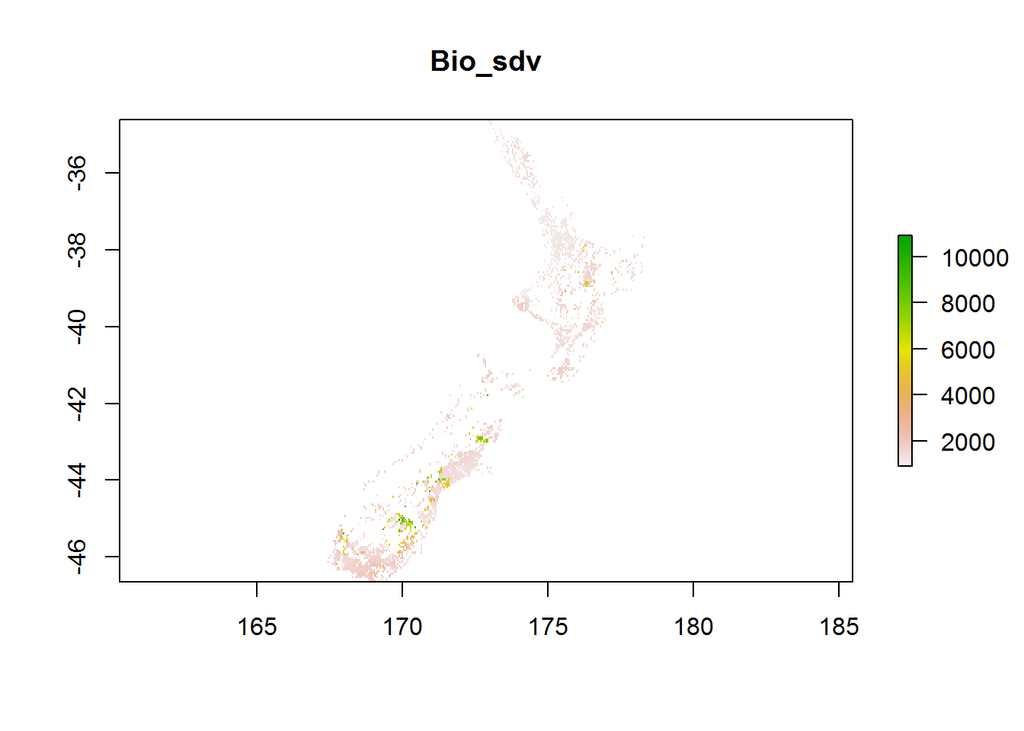

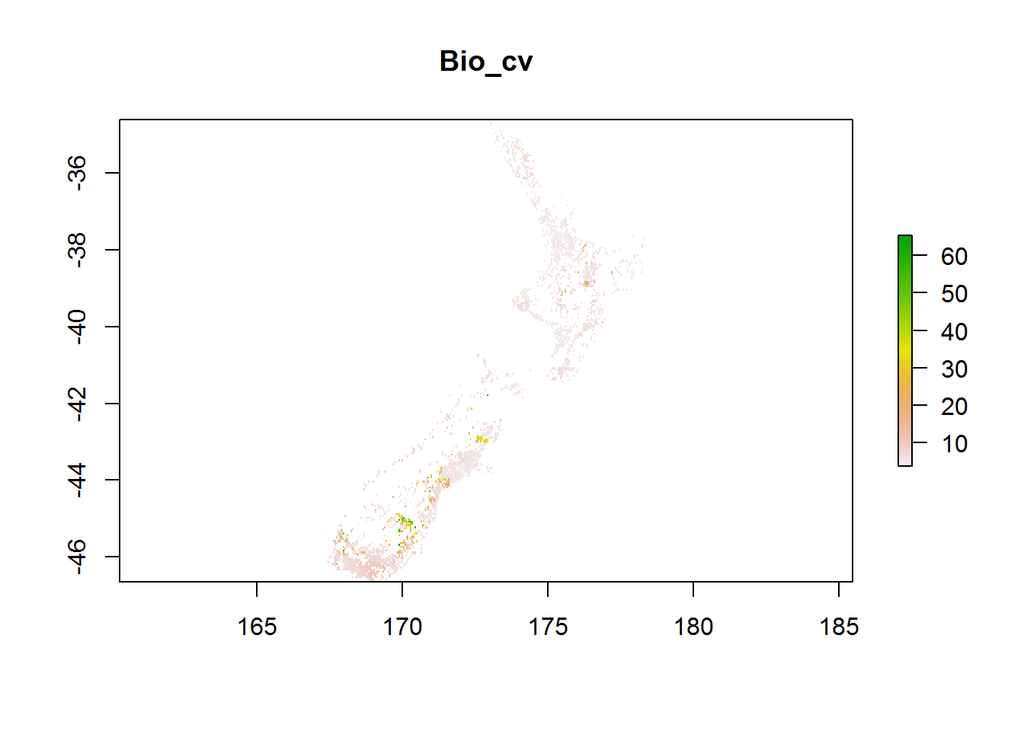

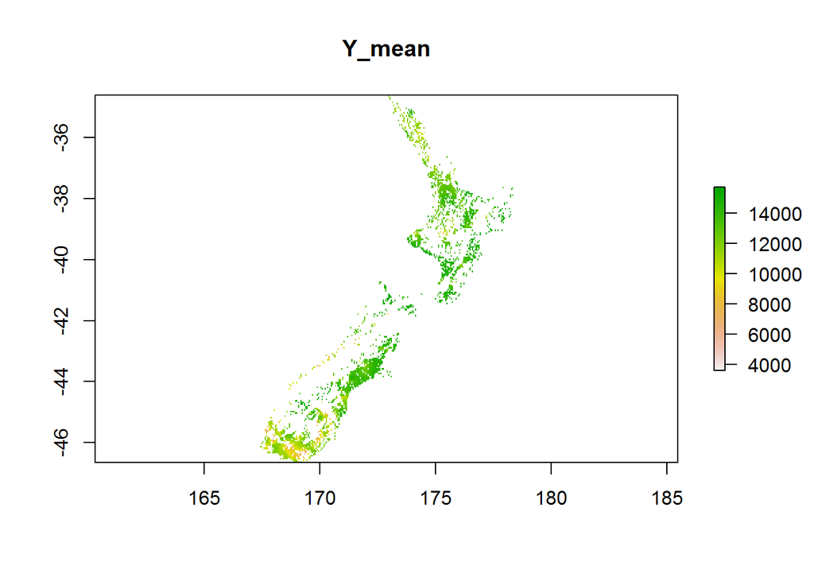

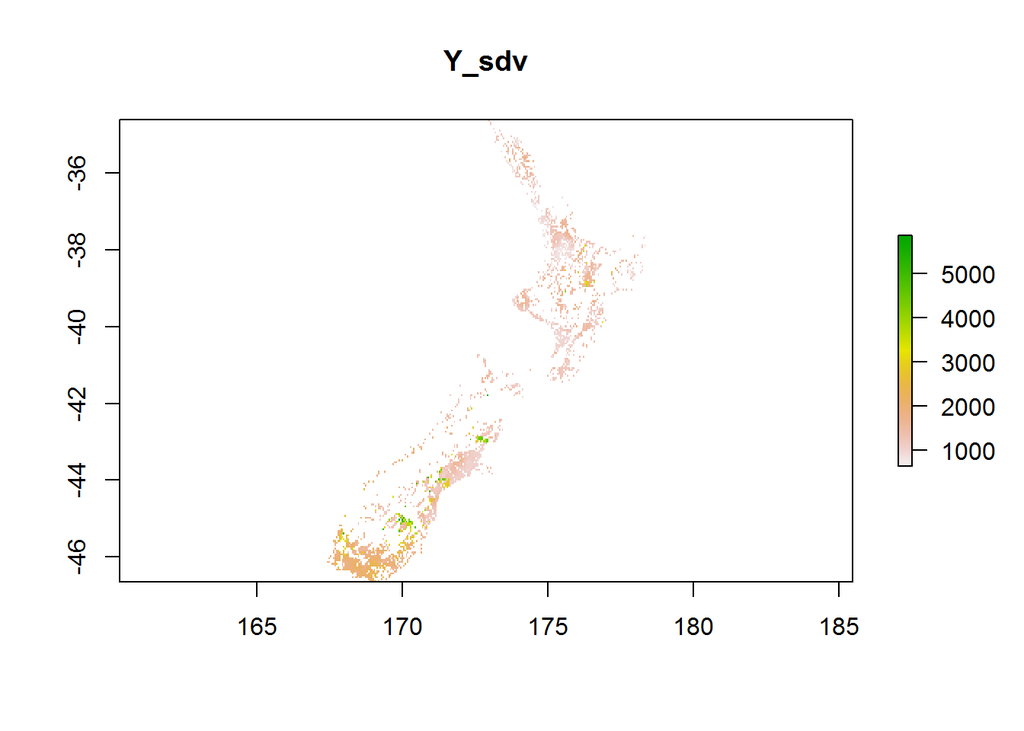

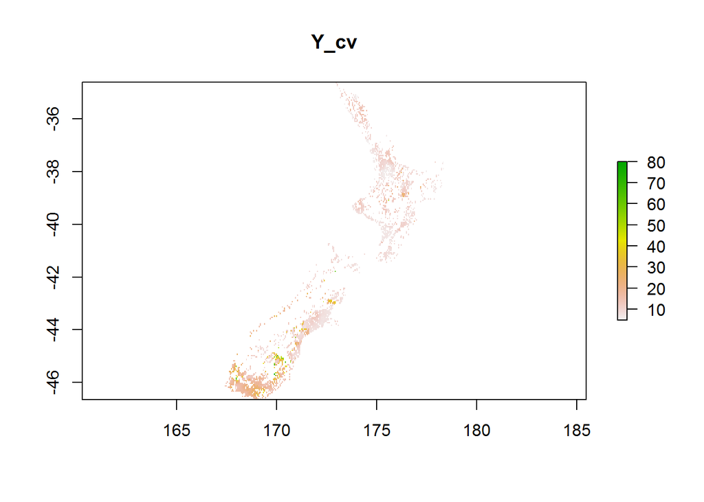

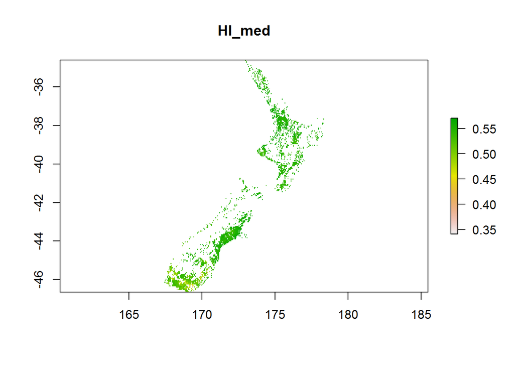

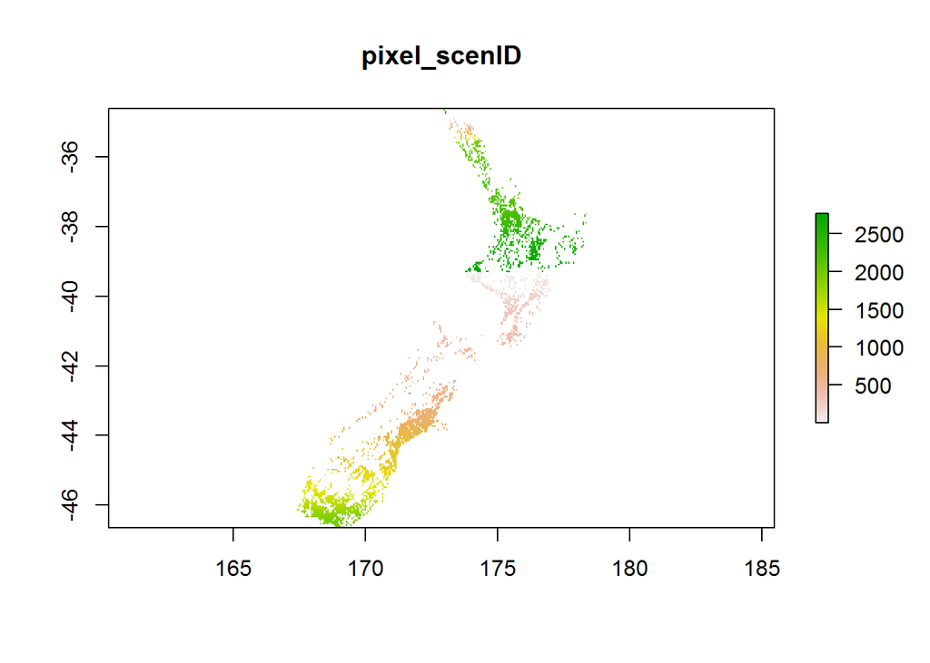

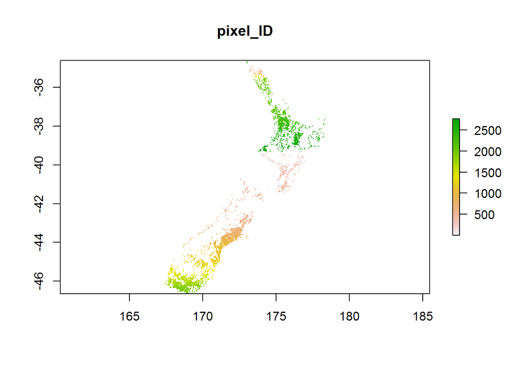

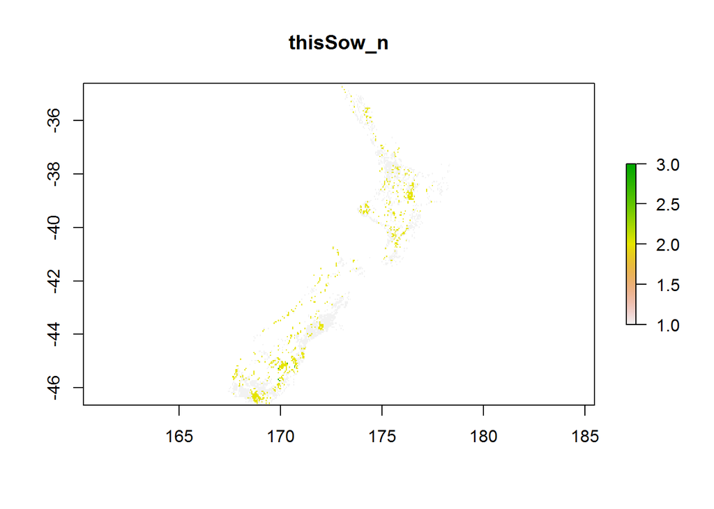

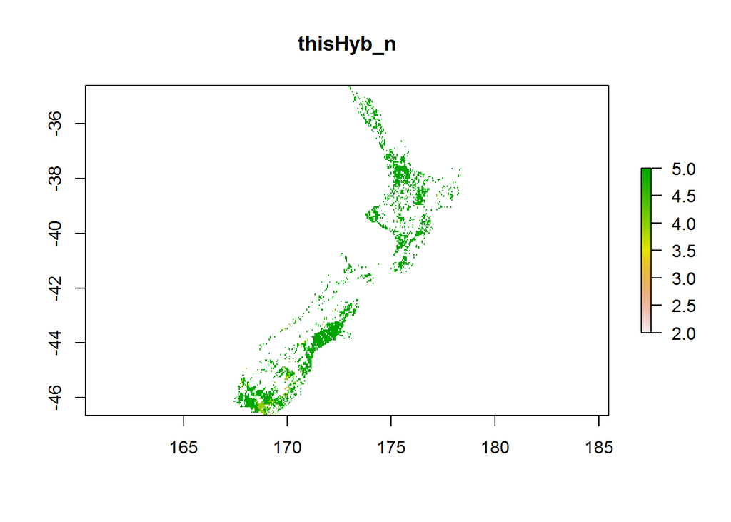

## Show maps when selecting run with **lowest variability**

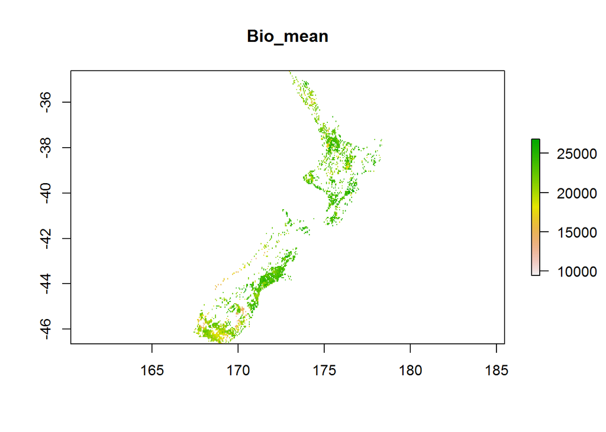

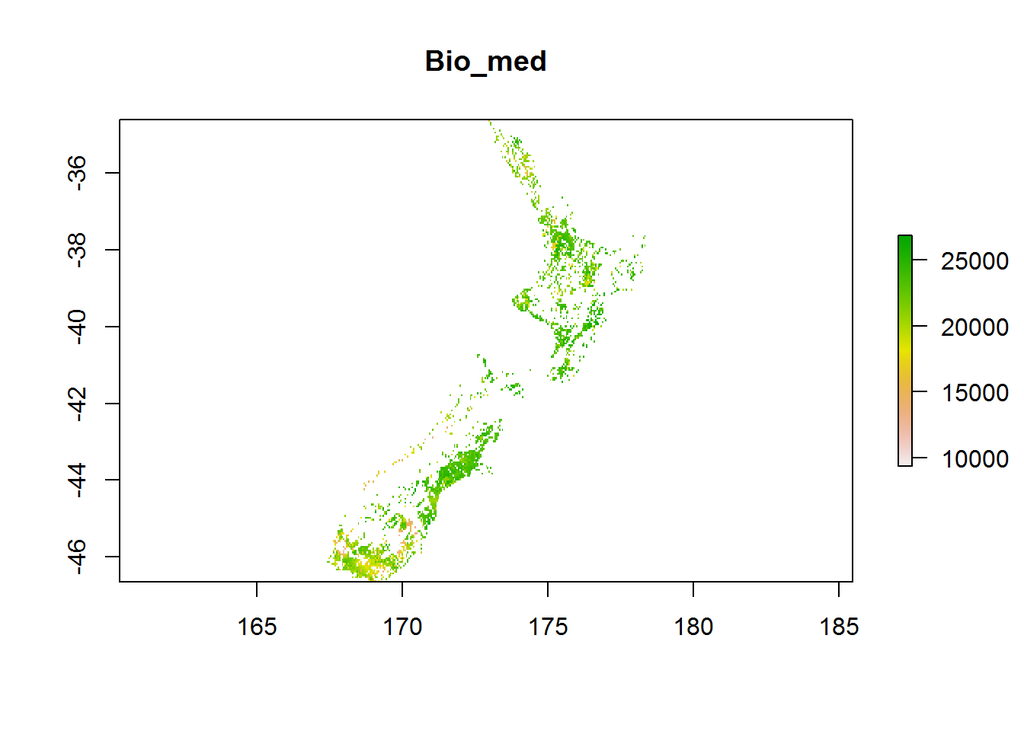

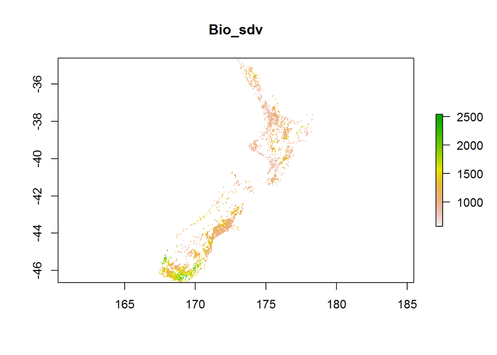

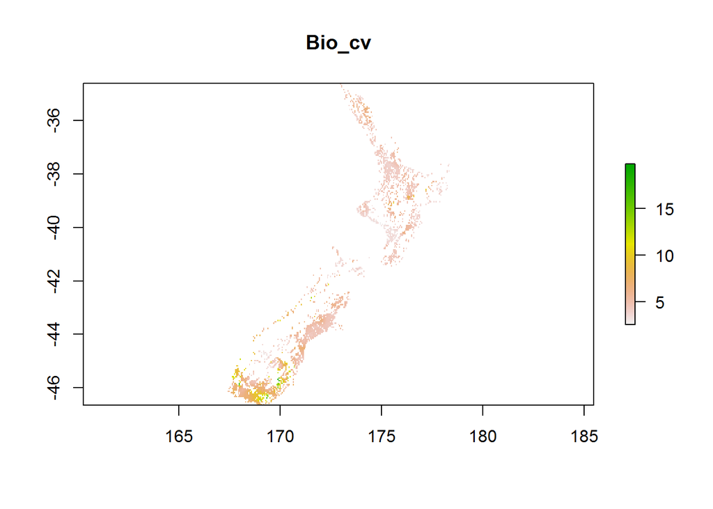

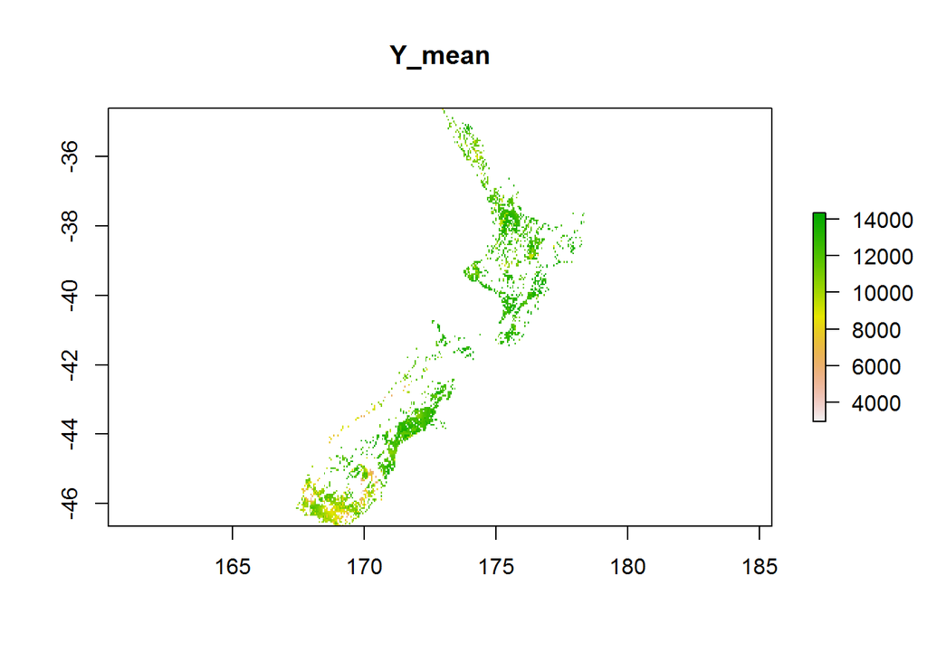

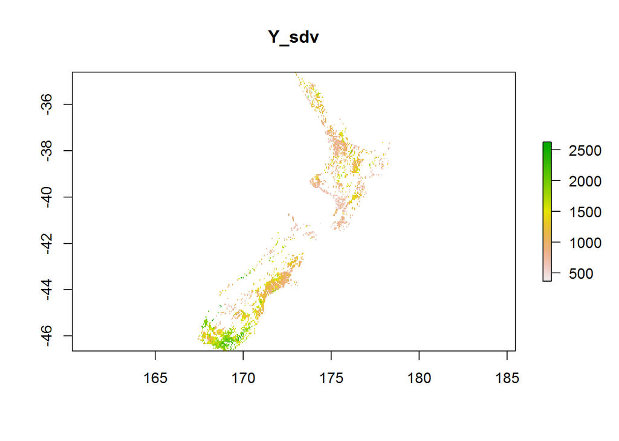

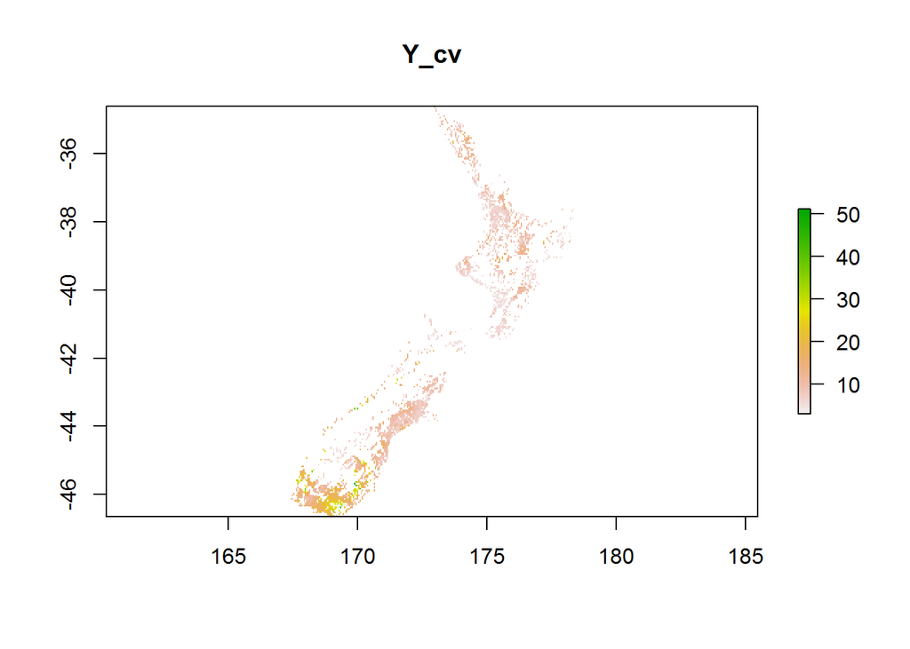

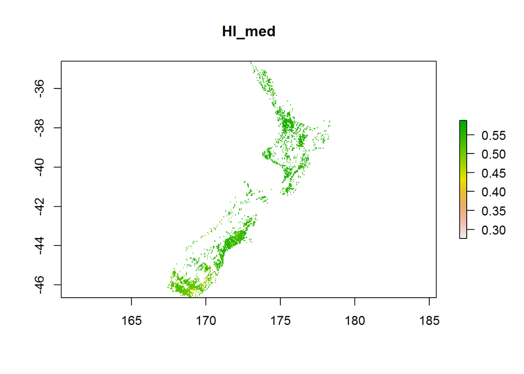

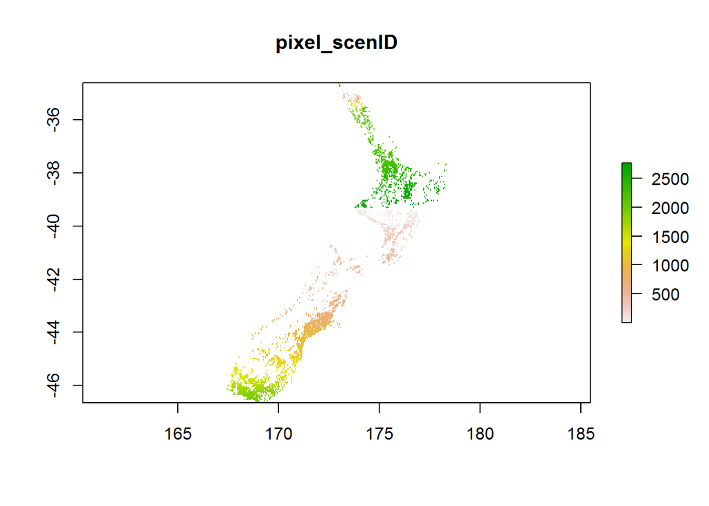

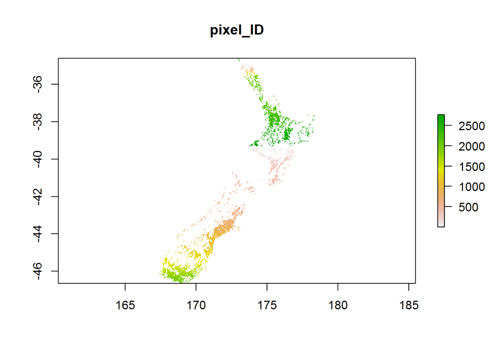

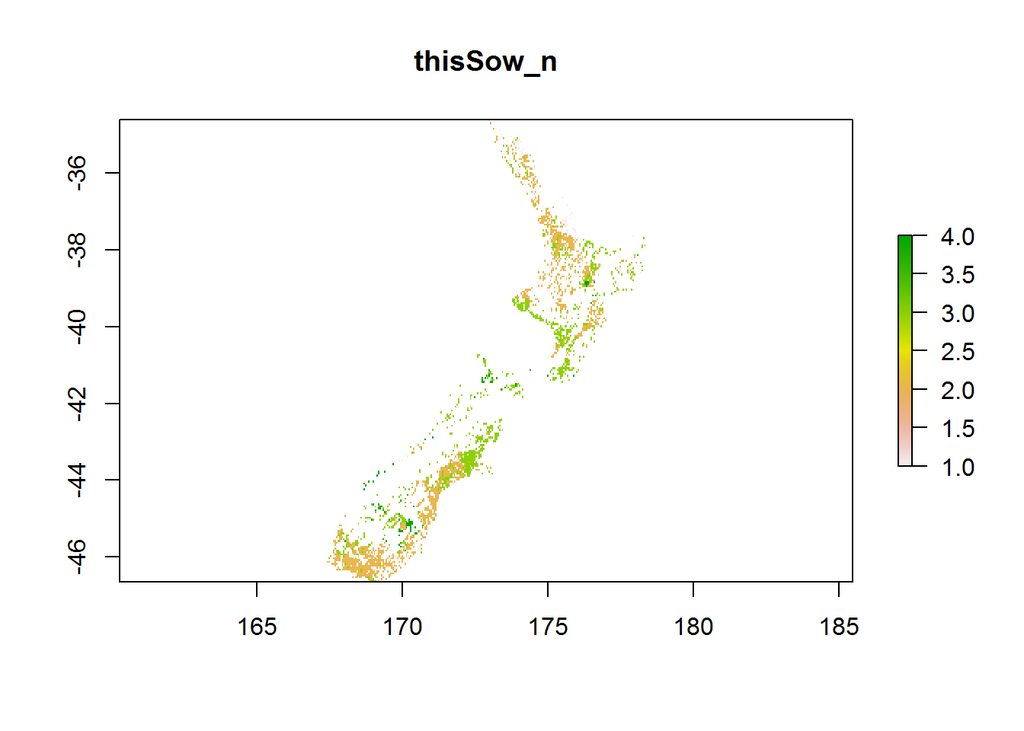

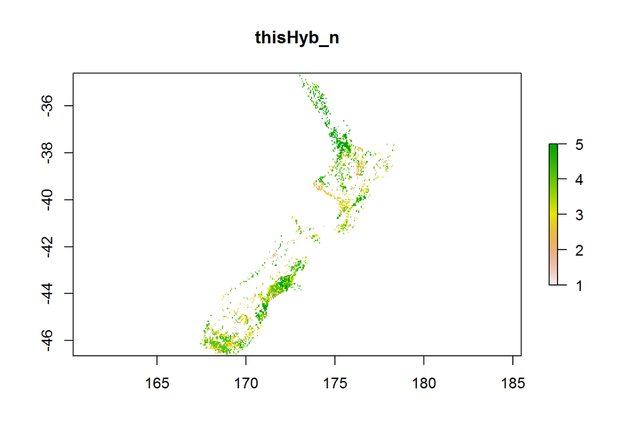

## Calculate the relative variability for factors

> How much of overall variation is coming from sowing date, hybrid and their interaction?

> Adapting Esther Meenken method of sensitivity analysis for that

> Run a ANOVA and retrive the Sums of Squares (SS) of each factor (2 main factors and the interaction)

> Display it as a relative proportion of total variation (% of total SS)

> This is the **Si index** summary:

```
##     thisLat          thisLong       Si_thisHyb       Si_thisSow
##  Min.   :-46.62   Min.   :167.4   Min.   : 0.608   Min.   :48.49
##  1st Qu.:-45.08   1st Qu.:170.1   1st Qu.: 8.423   1st Qu.:70.20
##  Median :-42.67   Median :172.8   Median :14.395   Median :75.96
##  Mean   :-41.84   Mean   :172.7   Mean   :15.579   Mean   :75.57
##  3rd Qu.:-38.67   3rd Qu.:175.4   3rd Qu.:21.971   3rd Qu.:81.50
##  Max.   :-34.62   Max.   :178.3   Max.   :40.295   Max.   :96.59
##    Si_Interac
##  Min.   : 2.610
##  1st Qu.: 7.410
##  Median : 8.261
##  Mean   : 8.848
##  3rd Qu.: 9.429
##  Max.   :24.888
```

```
## [1] 2766
```

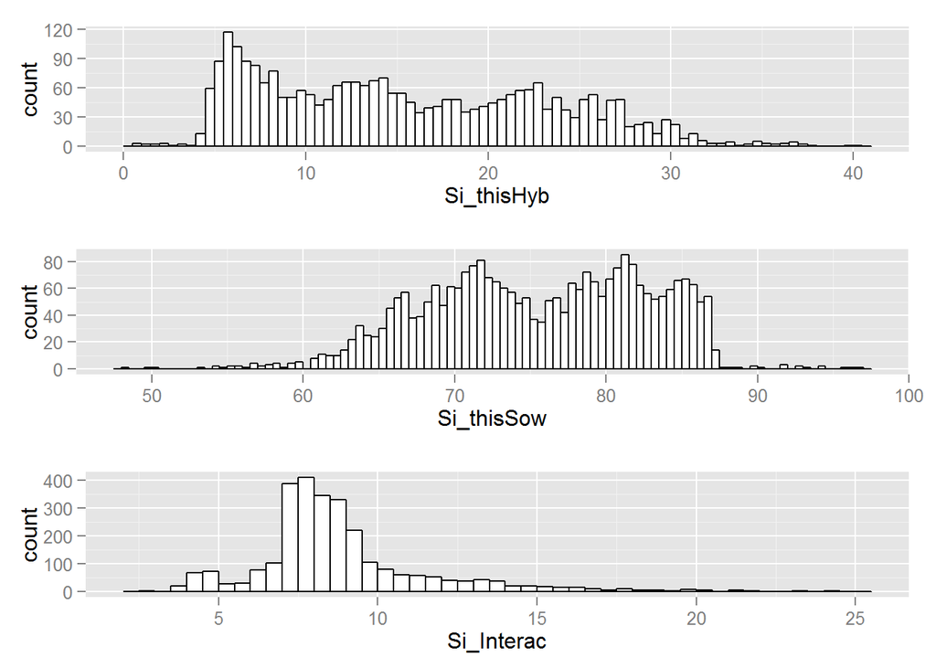

> Histograms show frequency of pixels in each range of Si for each factor and interactions

## Map Si index

> Si is the fraction of total sums of squares attributed to each main factor or interactions

> Let’s plot it:

[output not shown]

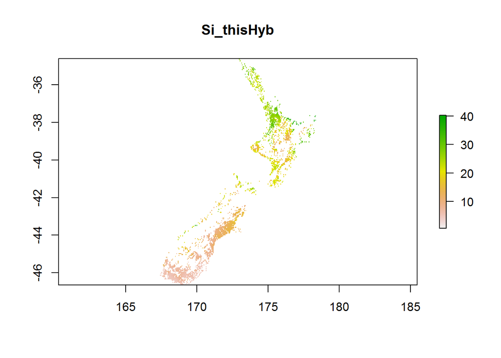

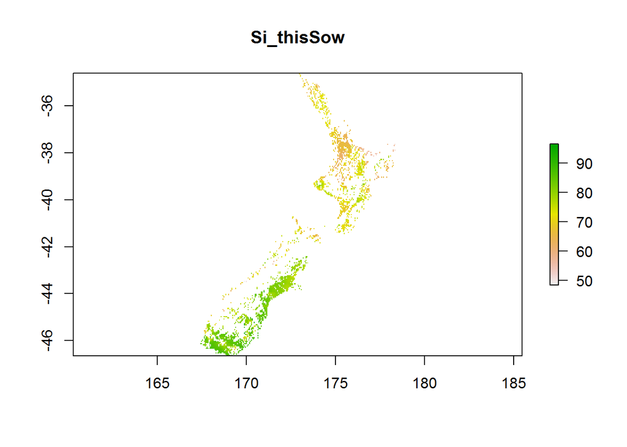

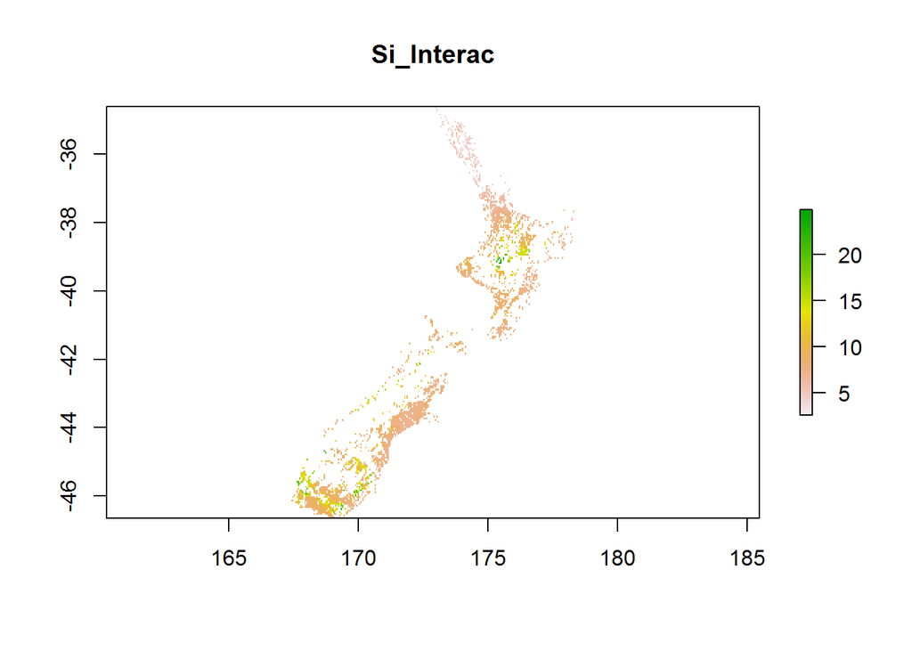